# Portfolio Investment Assignment

FN6901 Group Assignment

```r
library(conflicted)
library(tidyverse)
library(lubridate)
library(testit)
library(kableExtra)
library(frenchdata)
library(patchwork)
conflict_prefer('last', "dplyr")
conflict_prefer("lag", "dplyr")
conflict_prefer("filter", "dplyr")
options(dplyr.summarise.inform = FALSE)
```

# 0. Synopsis

- This is a backtesting exercise for investment of a stock portfolio.
- There are various types of backtesting: vectorized, event-based, etc. We use a hybrid method of vectorized and event-based. The trading signal is generated row-by-row (i.e. day-by-day) while the return is calculated in vector to speed up.
- In a nutshell, the value of the portfolio is calculated with following pipeline.

$$\left.\begin{matrix}
\text{Strategy Signal (Picker / Re-balance)} \rightarrow
\text{Allocation (weights)} \\
\text{Price} \rightarrow \text{Return} \\
\text{Return} \rightarrow \text{Cumulative Return} \\
\end{matrix}\right\}\rightarrow
\text{Value of the portfolio}$$

- Disclaimer: this is no an investment advise.

# 1. Overview

- SPDR sector ETFs divides S&P 500 into eleven sector index funds. https://www.sectorspdrs.com/. Vanguard has similar ETF https://investor.vanguard.com/investment-products/list/etfs?assetclass=sector_specialty
- We chose 9 among them and `SPY`, which is the S&P ETF.
- Investment horizon, long-term from 1999-11-01 to 2021-10-08.
- Strategy:
  - Equal-weighted with 1) no re-balance, 2) quarterly re-balance, 3) annual re-balance
  - Picker by alpha from Fama-French 3 factor model
- Note:
  - All equity position, no cash.
  - Do not load other library, use only the listed packages here.
  - Submit Rmd and the data files together
  - Use adjusted_close.

SPDR funds are managed by State Street Global Advisors (SSGA) with SPDR a trademark of Standard and Poor’s Financial Services LLC, a subsidiary of S&P Global. SPDR original stands for “Standard & Poor’s Depositary Receipts”.

For a long time, SPDR S&P 500 Trust ETF (SPY) was the largest ETF in the world. The sector ETFs divides the S&P 500 companies to attract investors for sector-specific investments. There are following ETFs and their industries.

- XLC: Communication Services Select Sector SPDR
- XLB: Materials Select Sector SPDR
- XLE: Energy Select Sector SPDR
- XLF: Financial Select Sector SPDR
- XLI: Industrial Select Sector SPDR
- XLK: Technology Select Sector SPDR
- XLP: Consumer Staples Select Sector SPDR
- XLU: Utilities Select Sector SPDR
- XLV: Health Care Select Sector SPDR
- XLRE: Real Estate Select Sector SPDR
- XLY: Consumer Discretionary Select Sector SPDR

Another notable mutual funds and ETF provider, Vanguard has similar offering.

- VOX: Communication Services ETF
- VCR: Consumer Discretionary ETF
- VDC: Consumer Staples ETF
- VDE: Energy ETF
- VFH: Financials ETF
- VHT: Health Care ETF
- VIS: Industrials ETF
- VGT: Information Technology ETF
- VAW: Materials ETF
- VNQ: Real Estate ETF
- VPU: Utilities ETF
- VTI: Vanguard Total Stock Market ETF (similar to SPY)

We will use SPDR’s data in this exercise.

## 1.1 Use downloaded data

Data have been pre-downloaded.

```r
# "XLC", "XLRE" has shorter history, skip them.
all_tickers <- c("XLB", "XLE", "XLF", "XLI", "XLK", "XLP", "XLU", "XLV", "XLY", "SPY")

length(all_tickers)
```

```
## [1] 10
```

```r
path_to_rds <- "./SPDR/"
```

## 1.2 Load and check

```r
# make sure all starts from the same time and same length.
# load each data as df_xxx

dd <- list()
dd_adjusted_close <- list()
for (tt in all_tickers) {
  dd[[tt]] <- readRDS(paste0(path_to_rds, tt, ".Rds"))
  dd_adjusted_close[[tt]] <- dd[[tt]] %>%
    select(adjusted_close) %>%
    rename_with(.fn = \(x) tt,
                .cols = "adjusted_close")
  print(paste(tt, min(dd[[tt]]$timestamp), max(dd[[tt]]$timestamp), nrow(dd[[tt]])))
  assert(min(dd[[tt]]$timestamp) == as.Date("1999-11-01"))
  assign(paste0("df_", tolower(tt)), dd[[tt]], envir = .GlobalEnv)
}
```

```
## [1] "XLB 1999-11-01 2021-10-08 5521"
## [1] "XLE 1999-11-01 2021-10-08 5521"
## [1] "XLF 1999-11-01 2021-10-08 5521"
## [1] "XLI 1999-11-01 2021-10-08 5521"
## [1] "XLK 1999-11-01 2021-10-08 5521"
## [1] "XLP 1999-11-01 2021-10-08 5521"
## [1] "XLU 1999-11-01 2021-10-08 5521"
## [1] "XLV 1999-11-01 2021-10-08 5521"
## [1] "XLY 1999-11-01 2021-10-08 5521"
## [1] "SPY 1999-11-01 2021-10-08 5521"
```

```r
(df_all <- bind_cols(select(dd[[tt]], timestamp),
                     do.call("bind_cols", dd_adjusted_close)))
```

| timestamp | XLB | XLE | XLF | XLI | XLK | XLP | XLU | XLV | XLY | SPY |
| --- | --- | --- | --- | --- | --- | --- | --- | --- | --- | --- |
| 1999-11-01 | 14.37990 | 15.85105 | 13.164280 | 18.13829 | 32.552332 | 14.94545 | 13.619074 | 20.29726 | 21.58920 | 90.31833 |
| 1999-11-02 | 14.51155 | 15.70439 | 13.148640 | 18.36328 | 32.406598 | 14.65111 | 13.492888 | 20.03805 | 21.42837 | 89.67287 |
| 1999-11-03 | 14.49360 | 15.62226 | 13.091290 | 18.23755 | 32.889821 | 15.02955 | 13.335156 | 20.12445 | 21.25222 | 90.27669 |
| 1999-11-04 | 14.67911 | 15.37000 | 13.247698 | 18.18461 | 33.135268 | 14.96347 | 13.267556 | 20.35486 | 21.51261 | 90.96372 |
| 1999-11-05 | 14.64919 | 14.99455 | 13.570939 | 18.28387 | 33.495767 | 15.07160 | 13.380222 | 20.26126 | 21.65812 | 91.85903 |
| 1999-11-08 | 14.51155 | 15.56359 | 13.497949 | 18.31034 | 33.833256 | 15.05357 | 13.465848 | 20.29726 | 21.58920 | 91.94231 |
| 1999-11-09 | 14.56541 | 15.89211 | 13.237271 | 18.32358 | 33.465086 | 14.79527 | 13.267556 | 20.16046 | 21.35944 | 91.07824 |
| 1999-11-10 | 14.60730 | 16.24410 | 13.033941 | 18.25078 | 34.048021 | 14.80128 | 13.321636 | 20.28286 | 21.44369 | 91.75489 |
| 1999-11-11 | 14.52352 | 16.24410 | 12.960951 | 18.32358 | 34.515904 | 14.80128 | 13.281076 | 20.52046 | 21.48964 | 92.27543 |
| 1999-11-12 | 14.56541 | 16.35556 | 13.524017 | 18.44931 | 34.707659 | 14.90340 | 13.321636 | 20.92367 | 21.99510 | 93.10824 |

[output cut: 5511 more lines]

```r
# Last row with return from each ETF
tail(df_all, 1) %>% select(!timestamp) / head(df_all, 1) %>% select(!timestamp) - 1
```

| XLB | XLE | XLF | XLI | XLK | XLP | XLU | XLV | XLY | SPY |
| --- | --- | --- | --- | --- | --- | --- | --- | --- | --- |
| 4.64538 | 2.568849 | 1.964081 | 4.565575 | 3.668175 | 3.687046 | 3.75583 | 5.254046 | 7.459323 | 3.847964 |

## 1.3 Background of last 20 years: Energy vs. Technology

- Energy was the rock star during 90s and 00s, abruptly stopped during GFC on the journey towards $200/bbl (never there).
- Technology was a prodigy from late 70s, stumbled in early 00s (dot com bubble), but now a rock star.
- Every sector has its peak and trough.

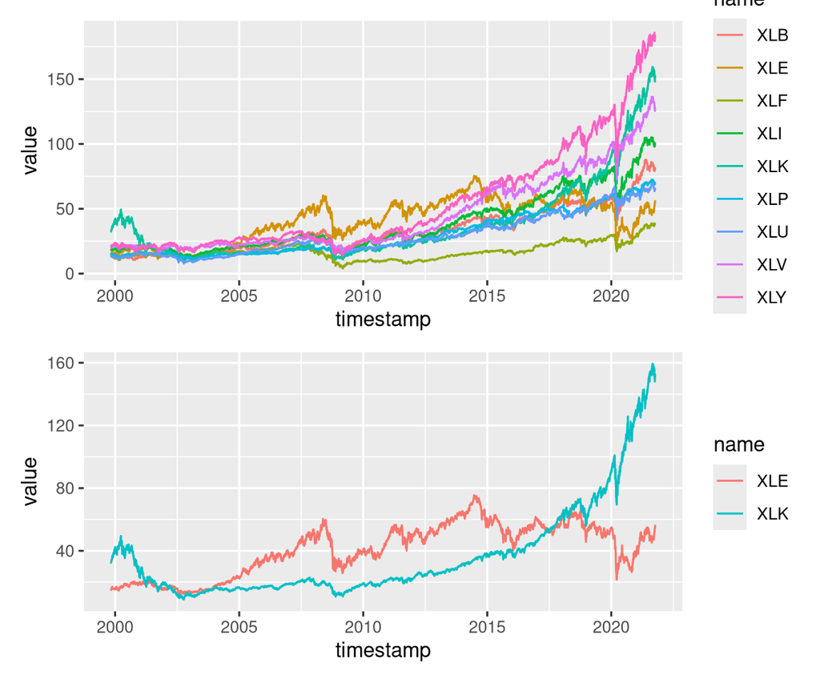

```r
p1 <- df_all %>%
  select(!SPY) %>%
  pivot_longer(cols = !timestamp) %>%
  ggplot(.) + geom_line(aes(timestamp, value, colour = name))

p2 <- df_all %>%
  select(timestamp, XLE, XLK) %>%
  pivot_longer(cols = !timestamp) %>%
  ggplot(.) + geom_line(aes(timestamp, value, colour = name))

p1 / p2
```

# 2. Equal-weighted Strategy (no re-balance)

Equal-weighted portfolio, also called `1/N` is a common non-biased strategy for asset allocation weight. With re-balance, it can show good performance over long term. We will do a no re-balance version first.

## 2.1 Compute daily return series

```r
len_tickers <- length(all_tickers)
ii <- 1
daily_ret <- tail(tibble(Date = dd[[1]]$timestamp), -1)
# XXX records each ETF's daily return
for (ii in 1:len_tickers) {
  daily_ret[all_tickers[ii]] <- tail(dd[[ii]]$adjusted_close / lag(dd[[ii]]$adjusted_close, 1) - 1, -1)
}
# XXX_cumret records each ETF's cumulative return
for (ii in 1:len_tickers) {
  daily_ret[paste0(all_tickers[ii], "_cumret")] <- cumprod(1 + daily_ret[all_tickers[ii]])
}
head(daily_ret)
```

| Date | XLB | XLE | XLF | XLI | XLK | XLP | XLU | XLV | XLY | SPY | XLB_cumret | XLE_cumret | XLF_cumret | XLI_cumret | XLK_cumret | XLP_cumret | XLU_cumret | XLV_cumret | XLY_cumret | SPY_cumret |
| --- | --- | --- | --- | --- | --- | --- | --- | --- | --- | --- | --- | --- | --- | --- | --- | --- | --- | --- | --- | --- |
| 1999-11-02 | 0.009155223 | -0.009252406 | -0.001188119 | 0.0124042320 | -0.004476909 | -0.019694534 | -0.009265387 | -0.012770486 | -0.007449450 | -0.0071464896 | 1.009155 | 0.9907476 | 0.9988119 | 1.012404 | 0.9955231 | 0.9803055 | 0.9907346 | 0.9872295 | 0.9925505 | 0.9928535 |
| 1999-11-03 | -0.001237113 | -0.005229735 | -0.004361618 | -0.0068468468 | 0.014911243 | 0.025830258 | -0.011690047 | 0.004311894 | -0.008220157 | 0.0067335691 | 1.007907 | 0.9855662 | 0.9944554 | 1.005472 | 1.0103676 | 1.0056270 | 0.9791529 | 0.9914863 | 0.9843916 | 0.9995390 |
| 1999-11-04 | 0.012799339 | -0.016147202 | 0.011947431 | -0.0029027576 | 0.007462687 | -0.004396483 | -0.005069280 | 0.011449016 | 0.012252252 | 0.0076103616 | 1.020807 | 0.9696521 | 1.0063366 | 1.002554 | 1.0179076 | 1.0012058 | 0.9741893 | 1.0028379 | 0.9964526 | 1.0071458 |
| 1999-11-05 | -0.002038320 | -0.024427481 | 0.024399843 | 0.0054585153 | 0.010879630 | 0.007226014 | 0.008491848 | -0.004598514 | 0.006763973 | 0.0098424094 | 1.018727 | 0.9459660 | 1.0308911 | 1.008026 | 1.0289821 | 1.0084405 | 0.9824619 | 0.9982263 | 1.0031926 | 1.0170586 |
| 1999-11-08 | -0.009395425 | 0.037949922 | -0.005378410 | 0.0014477018 | 0.010075567 | -0.001195695 | 0.006399461 | 0.001776830 | -0.003182461 | 0.0009066183 | 1.009155 | 0.9818653 | 1.0253465 | 1.009486 | 1.0393497 | 1.0072347 | 0.9887492 | 1.0000000 | 1.0000000 | 1.0179806 |
| 1999-11-09 | 0.003711340 | 0.021108179 | -0.019312476 | 0.0007228045 | -0.010881886 | -0.017158819 | -0.014725569 | -0.006739979 | -0.010642072 | -0.0093978696 | 1.012901 | 1.0025907 | 1.0055446 | 1.010215 | 1.0280396 | 0.9899518 | 0.9741893 | 0.9932600 | 0.9893579 | 1.0084138 |

## 2.2 Performance

### 2.2.1 Calculate Equity Curve (no re-balance)

`w` is the weight of each ETF in the portfolio.

```r
invest_tickers <- all_tickers[all_tickers != "SPY"]
len_invest <- length(invest_tickers)
w <- rep(1, len_invest) / len_invest
cat(paste0("w: ", paste0(round(w, 3), collapse = ",")))
```

```
## w: 0.111,0.111,0.111,0.111,0.111,0.111,0.111,0.111,0.111
```

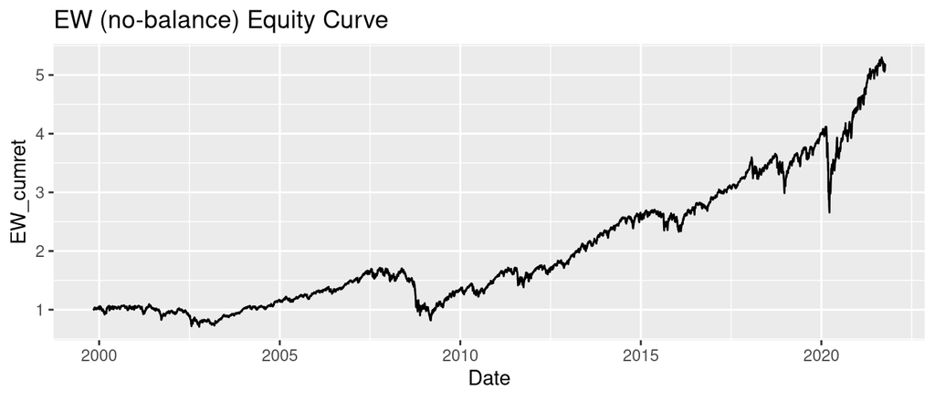

```r
# Test
# daily_ret %>% select(XLB_cumret:XLY_cumret) %>% tail(1) %>% as.matrix() %>% mean()

# We convert part of the data frame as matrix, perform the matrix multiplication and convert the matrix back to vector.
ew_cumret <- as.numeric(as.matrix(daily_ret %>% select(XLB_cumret:XLY_cumret)) %*% w)

ret_from_cumret <- function(cumret) {
  ret <- cumret / lag(cumret) - 1
  # filling the NA
  ret[1] <- cumret[1] - 1
  ret
}

# Test
# ret_from_cumret(daily_ret$XLB_cumret) - daily_ret$XLB

ew_ret <- ret_from_cumret(ew_cumret)

daily_ret["EW_cumret"] <- ew_cumret
daily_ret["EW"] <- ew_ret

daily_ret %>% ggplot(.) + geom_line(aes(Date, EW_cumret)) + ggtitle("EW (no-balance) Equity Curve")
```

### 2.2.2 Relative Performance between SPY v.s. EW (no re-balance)

1. Daily return for SPY v.s. EW

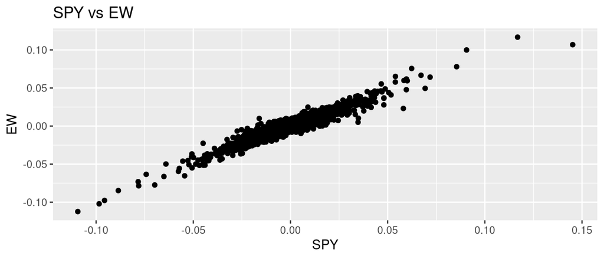

```r
# EW (no re-balance) has similar return as SPY
ggplot(daily_ret) + geom_point(aes(SPY, EW)) + ggtitle("SPY vs EW")
```

2. Cumulative return for SPY v.s. EW (no re-balance)

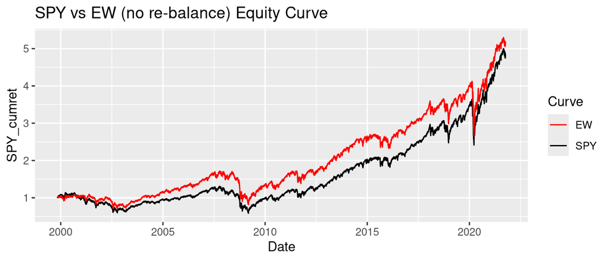

```r
# EW (no re-balance) has similar return as SPY, but higher.

daily_ret %>%
  ggplot(.) +
  geom_line(aes(Date, SPY_cumret, color = "SPY")) +
  geom_line(aes(Date, EW_cumret, color = "EW")) +
  ggtitle("SPY vs EW (no re-balance) Equity Curve") + labs(color = "Curve") +
  scale_color_manual(values = c("SPY" = "black", "EW" = "red"))
```

### 2.2.3 Metric (TODO)

```r
# annualized return for EW
(annual_ret_EW <- prod(daily_ret$EW + 1) ** (250 / length(daily_ret$EW)) - 1)
```

```
## [1] 0.07728365
```

```r
# annualized return for SPY
(annual_ret_SPY <- prod(daily_ret$SPY + 1) ** (250 / length(daily_ret$SPY)) - 1)
```

```
## [1] 0.07411031
```

```r
# Modified Sharpe ratio: EW vs SPY. I assume risk-free rate = 0 here as I did not find quality data source for it.

(SR_EW <- annual_ret_EW / sd(daily_ret$EW) / sqrt(250))
```

```
## [1] 0.4154788
```

```r
(SR_SPY <- annual_ret_SPY / sd(daily_ret$SPY) / sqrt(250))
```

```
## [1] 0.3788857
```

```r
# Calculate the Max Draw Down:

# max_drawdown <-
```

### 2.2.4 Details (TODO)

```r
# Rank all ETFs by its contribution to PnL over the entire period

# Rank all ETFs by its risk (i.e. max. draw down %) over the entire period
```

# 3. EW with Re-balance

Re-balance is an action to reset the weights so the allocation into each ETF has equal market value.

Without re-balance, some ETFs can grow heir value to a certain extend that reduces the diversification of our investment portfolio.

- The starting allocation for each ETF is 1/9.
- On the next re-balance day, calculate the value of the portfolio. For example, it has grown to 1.3 based on each ETF’s relative return during the previous period.
- The allocation for each ETF becomes 1.3/9.

If there is no re-balance (as shown earlier), weight is multiplied to the each ETF’s cumulative return. This is like that we allocated the capital equally on day 1 and future value is always 1/n * cumulative return. The overall cumulative return is the average of all ETFs’cumulative returns.

If we re-balance every day (a special case), weight is multiplied to each ETF’s daily return. This is like that the we equally divide the capital allocation for each ETF so the overall daily return is the averaged daily returns of all ETFs.

## 3.1 Re-balance everyday (a special case)

It has improved over the non re-balance from 7.7% to 8.5%.

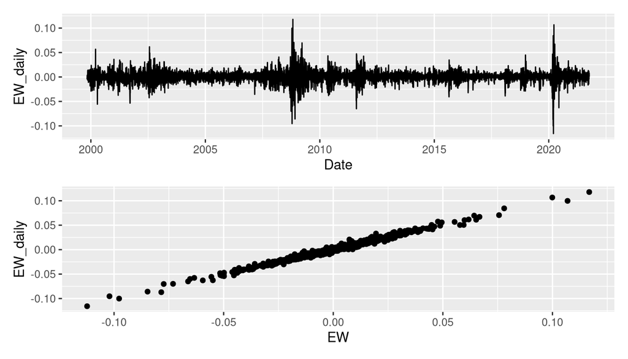

```r
daily_ret["EW_daily"] <- as.matrix(daily_ret %>% select(XLB:XLY)) %*% w
daily_ret["EW_daily_cumret"] <- cumprod(daily_ret[, "EW_daily", drop = TRUE] + 1)

p1 <- daily_ret %>% ggplot(.) + geom_line(aes(Date, EW_daily))
p2 <- daily_ret %>% ggplot(.) + geom_point(aes(EW, EW_daily))

p1 / p2
```

```r
# annualized return for EW_daily, higher than EW (no-balance)
prod(daily_ret$EW_daily + 1) ** (250 / length(daily_ret$EW_daily)) - 1
```

```
## [1] 0.08574442
```

## 3.2 Re-balance generalized

Step 1: Calculate the dates for the re-balance.

The re-balance could happen at fixed time intervals. To simplify the calculation, we set to have the last re-balance day happens on the last day (the re-balance on the last day would not have impact to the profit or loss) and derive the earlier re-balance days backward. I have written the custom function `calc_rebal_days()` to obtain the `rebal_days` vector. They are the n-th days on which re-balance is applied.

```r
calc_rebal_days <- function(nn, period) {
  rev(nn - (0:(round(nn / period, 0) - 1)) * period)
}

# Quarterly re-balance
# every 92 days
rebal_days <- calc_rebal_days(length(dd[[1]]$timestamp), 92)
head(rebal_days)
```

```
## [1]  93 185 277 369 461 553
```

```r
# Annual re-balance
# every 252 days
rebal_days <- calc_rebal_days(length(dd[[1]]$timestamp), 252)
head(rebal_days)
```

```
## [1]  229  481  733  985 1237 1489
```

Step 2: generalized code to calculate return from allocation and re-balance

Data frame `daily_ret` is composed of `Date`, `daily return matrix from XLB:XLY`, SPY, `cumret matrix from XLB:XLY` and EW results.

Previous `cumret` is directly calculate from each ETF’s daily return. With re-balance, `cumret` that records every ETF’s daily cumulative return in our portfolio will be calculated different.

We use a variable `prev_cumret` to record the previous day’s `cumret`.

Each row of `cumret` matrix is calculated from `prev_cumret * (1 + daily_return of each ETF)`.

When re-balance happens, we take that row of `cumret` and equalize each to be `1/N` of the row’s sum.

Below illustrates the row-by-row changes to `cumret` and `prev_cumret` suppose we have 4 ETFs and we initially 50/50 only to the first two.

```
  | cumret              | prev_cumret
                        | 0.5  0.5  0.0  0.0
1 | 0.4  0.6  0.0  0.0  | 0.4  0.6  0.0  0.0 <= daily
2 | 0.6  0.8  0.0  0.0  | 0.7  0.7  0.0  0.0 <= re-balance
3 | 0.8  0.6  0.0  0.0  | 0.0  0.0  0.7  0.7 <= switch ETF (implicit re-balance)
4 | 0.0  0.0  0.6  0.7  | 0.0  0.0  0.6  0.7
```

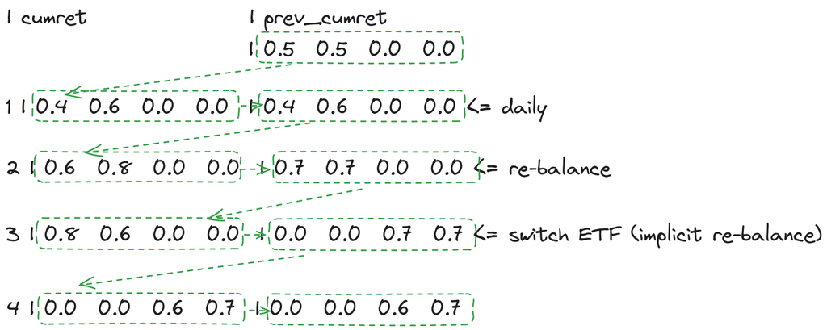

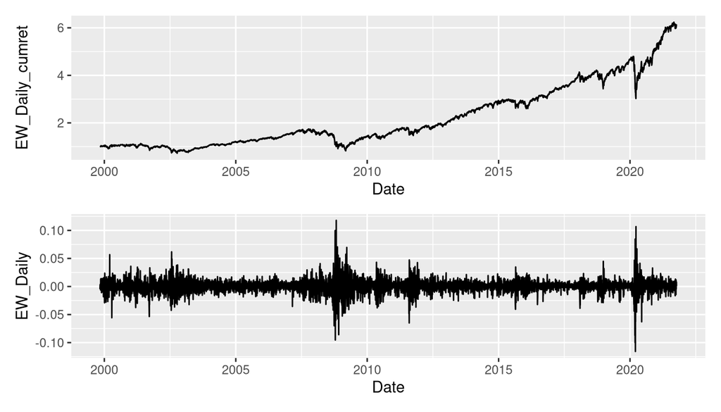

```r
# loc_cumret_matrix is where we have stored cumret for each ETF. We will re-write these columns' content.

loc_XLB <- which(colnames(daily_ret) == "XLB")
loc_XLY <- which(colnames(daily_ret) == "XLY")
loc_ret_matrix <- loc_XLB:loc_XLY

loc_XLB_cumret <- which(colnames(daily_ret) == "XLB_cumret")
loc_XLY_cumret <- which(colnames(daily_ret) == "XLY_cumret")
loc_cumret_matrix <- loc_XLB_cumret:loc_XLY_cumret

row_daily_ret <- nrow(daily_ret)

# We set to re-balance every day, hope to reproduce the same result as in ## 3.1
rebal_days <- 1:row_daily_ret
w0 <- w
for (ii in 1:row_daily_ret) {
  if (ii == 1) {
    prev_cumret <- matrix(w0, 1, len_invest)
  }
  daily_ret[ii, loc_cumret_matrix] <- prev_cumret * as.matrix(1 + daily_ret[ii, loc_ret_matrix])

  if (ii %in% rebal_days) {
    # when re-balance, multiple weights with cumret
    port_sum <- sum(daily_ret[ii, loc_cumret_matrix])
    daily_ret[ii, loc_cumret_matrix] <- matrix(rep(port_sum, len_invest) / len_invest, 1, len_invest)
  }
  prev_cumret <- as.matrix(daily_ret[ii, loc_cumret_matrix])
}


# EW_Daily_cumret matches EW_daily_cumret. And EW_Daily matches EW_daily.
daily_ret["EW_Daily_cumret"] <- rowSums(as.matrix(daily_ret[loc_cumret_matrix]))
daily_ret["EW_Daily"] <- ret_from_cumret(daily_ret[, "EW_Daily_cumret", drop = TRUE])

p1 <- daily_ret %>% ggplot(.) + geom_line(aes(Date, EW_Daily_cumret))
p2 <- daily_ret %>% ggplot(.) + geom_line(aes(Date, EW_Daily))

p1 / p2
```

## 3.3 TODO

Now we have a generalized allocate and re-balance algorithm. Re-balance daily would incur large amount of transaction cost. We will lower the re-balance frequency. Test for two EW strategies with different re-balance period: quarterly and annually. Perform similar analysis as ## 2.2 Performance.

Hint: 1). create re-usable functions. 2) move the functions to a separate script file to keep the R Markdown file clean, use `source()` to load any R script file in the R markdown.

# 4. Fama-French Selection

This allocation method is based on Fama-French’s data.

You can assume 21 days per month. For the first three months, keep all in cash.

Below is demo code to get started.

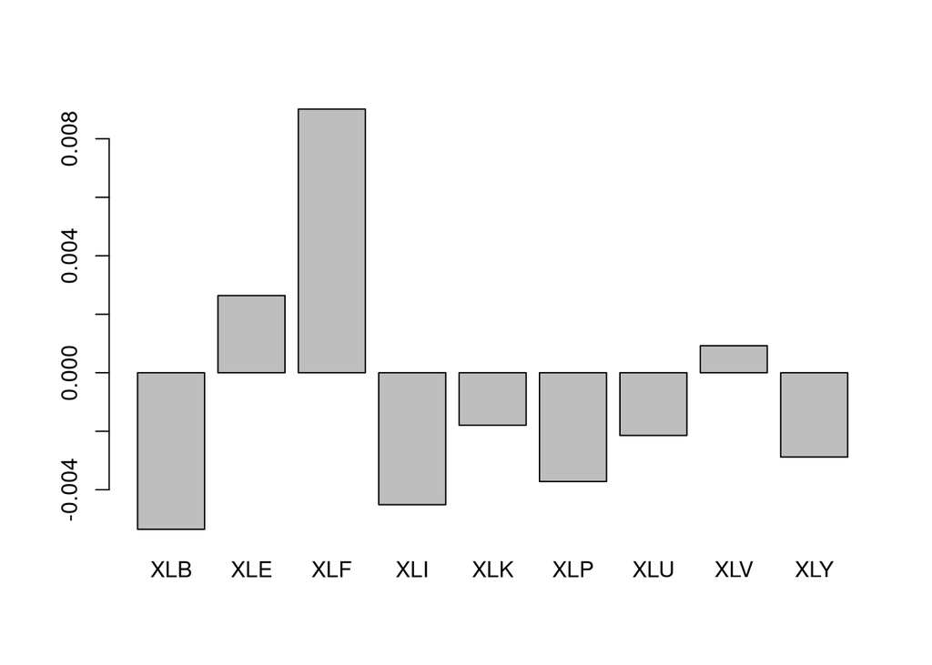

```r
# Download data
ff_data_daily <- tryCatch(
  {
    ff <- download_french_data("Fama/French 3 Factors [Daily]",
                               dir = ".", overwrite = FALSE)
    df <- ff$subsets$data[[1]] %>% mutate(date = ymd(date))
    saveRDS(df, file = "F-F_Research_Data_Factors_Daily_CSV.Rda")
    df
  },
  error = function(e) {
    df <- readRDS("F-F_Research_Data_Factors_Daily_CSV.Rda")
    df
  }
)

# Merge with ETF's daily return data
daily_ret_ff <- left_join(daily_ret, ff_data_daily, by = c("Date" = "date"))

rebal_days <- calc_rebal_days(length(dd[[1]]$timestamp), 21)

for (rebal_day_n in 2:length(rebal_days)) {
  # Leave the first three months with no allocation
  if (rebal_days[rebal_day_n] < 61) {
    next
  }
  fitting_period <- (rebal_days[rebal_day_n] - 6):rebal_days[rebal_day_n]
  alphas <- c()
  for (ii in 1:(len_tickers - 1)) {
    ticker <- all_tickers[ii]
    ff_lreg <- lm(paste0(ticker, " ~ `Mkt-RF` + SMB + HML"),
                  data = daily_ret_ff[fitting_period, ])
    alphas <- c(alphas, as.numeric(ff_lreg$coefficients[1]))
  }
  names(alphas) <- head(all_tickers, -1)
  break # break is added temporarily in the demo code so the loop can stop after the first round.
}

barplot(alphas)
```